# SAS Midterm in R

Steven Susana-Castillo

March 13, 2019

## Purpose of Analysis

I want to practice my R coding skills for data analysis. The assignment I am basing this analysis off was done in SAS. I was advised to recreate the results using R.

The goal of the assignment was to do the preliminary work needed to explore the associations between pet ownership and history of major depression among those ages 21-39. The data comes NHANES III.

Although the original assignment did not include models and visuals, I have decided to use this as an opportunity to practice my model building and data visualization.

## Importing Data

We were given a SAS file and a fixed-width text file to merge for the analysis.

```r
rawWtHtDepr<- read_sas("C:/Users/Steven S-C/Desktop/R Practice/AAMIE Midterm/Original/exam.sas7bdat")
rawInterview<- read_fwf(file="C:/Users/Steven S-C/Desktop/R Practice/AAMIE Midterm/Original/INTERVW.TXT",
                       skip=0,
                       fwf_widths(c(5, 2, 1, 1, 2, 2, 2, 2)))
colnames(rawInterview)<- c("SEQN","HSAGEIR","HSSEX","DMARETHN","HFA12","HAC1A","HAC1E","HFE7")
```

## Merging Datasets and Cleaning

The two datasets will now be merged by SEQN, which is the unique patient identifier. Our independent variable is pet ownership or HFE7. And our dependent variables are the questions on depression or MQPDYSFR+MQPDGPSW. We are also removing responses that are missing, reponses indicating missing, or nonsense.

The variables in the merged dataset include: SEQN: ID, HSAGEIR: Age (continuous), HSSEX: Sex, DMARETHN: Race/Ethnicity (White, Black, Mexican-American, Other), HFA12: Marital Status, HAC1A: Arthritis Status, HAC1E: Asthma Status, HFE7: Pet Ownership Status, BMPWT: Weight in kg, BMPHT: Height in cm, MQPDYSFR: Dysphoria in a 2-week period, & MQPDGPSW: Total number of depression symptoms.

```r
mergeData<- merge(rawInterview,rawWtHtDepr, by="SEQN")
mergeData1<- na.omit(mergeData, cols=c("HFE7","MQPDYSFR","MQPDGPSW"))
mergeData2<- mergeData1[!mergeData1$HFE7==8,]
mergeData2<- mergeData2[!mergeData2$MQPDYSFR==8,]
mergeData2<- mergeData2[!mergeData2$MQPDGPSW==88,]
mergeData2<- mergeData2[!mergeData2$BMPWT==888888,]
mergeData2<- mergeData2[!mergeData2$BMPHT==888888,]
```

## Results for Descriptive Table of Sample by Pet Ownership Status

We were assigned an empty table shell to fill. The characteristics age, gender, race/ethnicity, marital status, arthritis, asthma and BMI are split by pet ownership status. For age and BMI, a t-test will be used to identify significance since the distributions meet criteria. The rest of the variables will be evaluated using a chi-squared test.

```r
mergeData2$Height<- mergeData2$BMPHT/100
mergeData2$BMI<- mergeData2$BMPWT/(mergeData2$Height^2)
mergeData2$Marital[mergeData2$HFA12<=3]<- "0"
mergeData2$Marital[mergeData2$HFA12>=4]<- "1"

aggregate(HSAGEIR~HFE7, mergeData2, mean)
aggregate(HSAGEIR~HFE7, mergeData2, sd)
t.test(HSAGEIR~HFE7, data=mergeData2, paired=FALSE)

aggregate(HSSEX==1~HFE7, mergeData2, sum)
aggregate(HSSEX==2~HFE7, mergeData2, sum)
chisq.test(mergeData2$HSSEX, mergeData2$HFE7, correct=FALSE)

aggregate(DMARETHN==1~HFE7, mergeData2, sum)
aggregate(DMARETHN==2~HFE7, mergeData2, sum)
aggregate(DMARETHN==3~HFE7, mergeData2, sum)
aggregate(DMARETHN==4~HFE7, mergeData2, sum)
chisq.test(mergeData2$DMARETHN, mergeData2$HFE7, correct=FALSE)

aggregate(Marital==1~HFE7, mergeData2, sum)
aggregate(Marital==0~HFE7, mergeData2, sum)
chisq.test(mergeData2$Marital, mergeData2$HFE7, correct=FALSE)

aggregate(HAC1A==1~HFE7, mergeData2, sum)
aggregate(HAC1A==2~HFE7, mergeData2, sum)
chisq.test(mergeData2$HAC1A, mergeData2$HFE7, correct=FALSE)

aggregate(HAC1E==1~HFE7, mergeData2, sum)
aggregate(HAC1E==2~HFE7, mergeData2, sum)
chisq.test(mergeData2$HAC1E, mergeData2$HFE7, correct=FALSE)

aggregate(BMI~HFE7, mergeData2, mean)
aggregate(BMI~HFE7, mergeData2, sd)
t.test(BMI~HFE7, data=mergeData2, paired=FALSE)
```

The total sample size is 6,225. Missing data were excluded from the descriptive analysis except for the marital status variable. There were 1,983 pet owners and 4,242 non-pet owners. The significance threshold is set at the p value of <.05. There seems to be an association between pet ownership status and age, gender, race/ethnicity, marital status, arthritis, and asthma. Pet owners on average were older. Men constituted 42.6% of pet owners and 46.5% of non-pet owners. Non-Hispanic white were more likely to be pet owners while Non-Hispanic Black, Mexican-American and Other are less likely to be pet owners. Partnered individuals constituted 65.2% of pet owners and 56.6% of non-pet owners. Individuals with arthritis constituted 7.4% of pet owners and 4.2% of non-pet owners. Individuals with asthma constituted 8.7% of pet owners and 5.3% of non-pet owners. Pet ownership status did not seem to be associated with body mass index (BMI).

## Results for Unadjusted Associations to History of Major Depression

Major Depression’s criteria is: affirmative dysphoria (or MQPDYSFR) + 4<= symptom groups (MQPDGPSW); ELSE negative dysphoria OR affirmative dysphoria + <4 symptom groups.

Age was converted into a categorical variable for 21-29 and 30-39. BMI was converted into a categorical variable for <25, 25-<30, >=30.

Significance was identified using a chi-square test for each variable.

```r
mergeData2$MDepr<- ifelse((mergeData2$MQPDYSFR==1) & (mergeData2$MQPDGPSW>=4),1,
                   ifelse((mergeData2$MQPDYSFR==0),0,
                   ifelse((mergeData2$MQPDYSFR==1) & (mergeData2$MQPDGPSW<4), 0, 0)))

mergeData2$YOage<- ifelse((mergeData2$HSAGEIR>=21) & (mergeData2$HSAGEIR<30), 0,
                    ifelse((mergeData2$HSAGEIR>=30) & (mergeData2$HSAGEIR<=39), 1, 1))

mergeData2$BMICat<- ifelse((mergeData2$BMI<25), 0,
                    ifelse((mergeData2$BMI>=25) & (mergeData2$BMI<30), 1,
                    ifelse((mergeData2$BMI>=30),2,2)))

aggregate(MDepr==1~HFE7, mergeData2, sum)
chisq.test(mergeData2$MDepr, mergeData2$HFE7, correct=FALSE)

aggregate(MDepr==1~YOage, mergeData2, sum)
chisq.test(mergeData2$MDepr, mergeData2$YOage, correct=FALSE)

aggregate(MDepr==1~HSSEX, mergeData2, sum)
chisq.test(mergeData2$MDepr, mergeData2$HSSEX, correct=FALSE)

aggregate(MDepr==1~DMARETHN, mergeData2, sum)
chisq.test(mergeData2$MDepr, mergeData2$DMARETHN, correct=FALSE)

aggregate(MDepr==1~Marital, mergeData2, sum)
chisq.test(mergeData2$MDepr, mergeData2$Marital, correct=FALSE)

aggregate(MDepr==1~HAC1A, mergeData2, sum)
chisq.test(mergeData2$MDepr, mergeData2$HAC1A, correct=FALSE)

aggregate(MDepr==1~HAC1E, mergeData2, sum)
chisq.test(mergeData2$MDepr, mergeData2$HAC1E, correct=FALSE)

aggregate(MDepr==1~BMICat, mergeData2, sum)
chisq.test(mergeData2$MDepr, mergeData2$BMICat, correct=FALSE)
```

The significance threshold is set at the p value of <.05. There seems to be an association between pet ownership, age, gender, race/ethnicity, marital status, arthritis and asthma regarding a history of major depression unadjusted for other variables. Pet owners were more likely than non-pet owners to have a history of major depression. Older individuals (ages 30-39) were more likely than younger individuals (ages 21-29) to have a history of major depression. Women were more likely than men to have a history of major depression. Non-Hispanic whites were most likely to have a history of major depression while Non-Hispanic Blacks were least likely to have a history of major depression. Not partnered individuals were more likely than partnered individuals to have a history of major depression. Those with arthritis were more likely than those who do not to have a history of major depression. Those with asthma were more likely than those who do not to have a history of major depression. There does not seem to be an association between history of major depression and BMI unadjusted for other variables.

## Building Regression between Pet Ownership and History of Major Depression

The null hypothesis is that pet ownership among those ages 21-39 does not have an association with a history of major depression after adjusting for significant predictors. I am setting my significance threshold at p<0.05.

```r
mergeData2$Pet[mergeData2$HFE7==1]<- "1"
mergeData2$Pet[mergeData2$HFE7==2]<- "0"
mergeData2$Arthritis[mergeData2$HAC1E==1]<- "1"
mergeData2$Arthritis[mergeData2$HAC1E==2]<- "0"
mergeData2$Asthma[mergeData2$HAC1A==1]<- "1"
mergeData2$Asthma[mergeData2$HAC1A==2]<- "0"
mergeData2$Men[mergeData2$HSSEX==1]<- "0"
mergeData2$Men[mergeData2$HSSEX==2]<- "1"
```

```r
FullModel<- glm(MDepr~Pet+YOage+Men+DMARETHN+Marital+Arthritis+Asthma+BMICat, family=binomial, data=mergeData2)
summary(FullModel)
```

```
##
## Call:
## glm(formula = MDepr ~ Pet + YOage + Men + DMARETHN + Marital +
##     Arthritis + Asthma + BMICat, family = binomial, data = mergeData2)
##
## Deviance Residuals:
##     Min       1Q   Median       3Q      Max
## -0.9598  -0.4819  -0.3920  -0.3196   2.5960
##
## Coefficients:
##             Estimate Std. Error z value Pr(>|z|)
## (Intercept) -2.90863    0.16432 -17.701  < 2e-16 ***
## Pet1         0.19740    0.09526   2.072  0.03824 *
## YOage        0.15864    0.09273   1.711  0.08713 .
## Men1         0.69570    0.09687   7.182 6.88e-13 ***
## DMARETHN    -0.14194    0.05348  -2.654  0.00795 **
## Marital1     0.46017    0.09100   5.057 4.26e-07 ***
## Arthritis1   0.41212    0.15550   2.650  0.00804 **
## Asthma1      0.64015    0.15580   4.109 3.98e-05 ***
## BMICat       0.04608    0.05579   0.826  0.40887
## ---
## Signif. codes:  0 '***' 0.001 '**' 0.01 '*' 0.05 '.' 0.1 ' ' 1
##
## (Dispersion parameter for binomial family taken to be 1)
##
##     Null deviance: 3802.3  on 6224  degrees of freedom
## Residual deviance: 3666.7  on 6216  degrees of freedom
## AIC: 3684.7
##
## Number of Fisher Scoring iterations: 5
```

```r
RedModel<- glm(MDepr~Pet+Men+DMARETHN+Marital+Arthritis+Asthma, family=binomial, data=mergeData2)
summary(RedModel)
```

```
##
## Call:
## glm(formula = MDepr ~ Pet + Men + DMARETHN + Marital + Arthritis +
##     Asthma, family = binomial, data = mergeData2)
##
## Deviance Residuals:
##     Min       1Q   Median       3Q      Max
## -0.9229  -0.4854  -0.3958  -0.3227   2.5504
##
## Coefficients:
##             Estimate Std. Error z value Pr(>|z|)
## (Intercept) -2.78668    0.15227 -18.301  < 2e-16 ***
## Pet1         0.20342    0.09507   2.140  0.03238 *
## Men1         0.70532    0.09665   7.298 2.92e-13 ***
## DMARETHN    -0.14207    0.05294  -2.683  0.00729 **
## Marital1     0.42841    0.08950   4.787 1.70e-06 ***
## Arthritis1   0.42693    0.15513   2.752  0.00592 **
## Asthma1      0.67370    0.15477   4.353 1.34e-05 ***
## ---
## Signif. codes:  0 '***' 0.001 '**' 0.01 '*' 0.05 '.' 0.1 ' ' 1
##
## (Dispersion parameter for binomial family taken to be 1)
##
##     Null deviance: 3802.3  on 6224  degrees of freedom
## Residual deviance: 3670.8  on 6218  degrees of freedom
## AIC: 3684.8
##
## Number of Fisher Scoring iterations: 5
```

```r
exp(cbind(OR = coef(RedModel), confint(RedModel)))
```

```
##                     OR      2.5 %     97.5 %
## (Intercept) 0.06162568 0.04558534 0.08281425
## Pet1        1.22558193 1.01607571 1.47518687
## Men1        2.02448664 1.67829585 2.45192338
## DMARETHN    0.86755950 0.78164380 0.96199095
## Marital1    1.53481107 1.28780531 1.82929043
## Arthritis1  1.53253865 1.12073240 2.06086392
## Asthma1     1.96147436 1.43688462 2.63834040
```

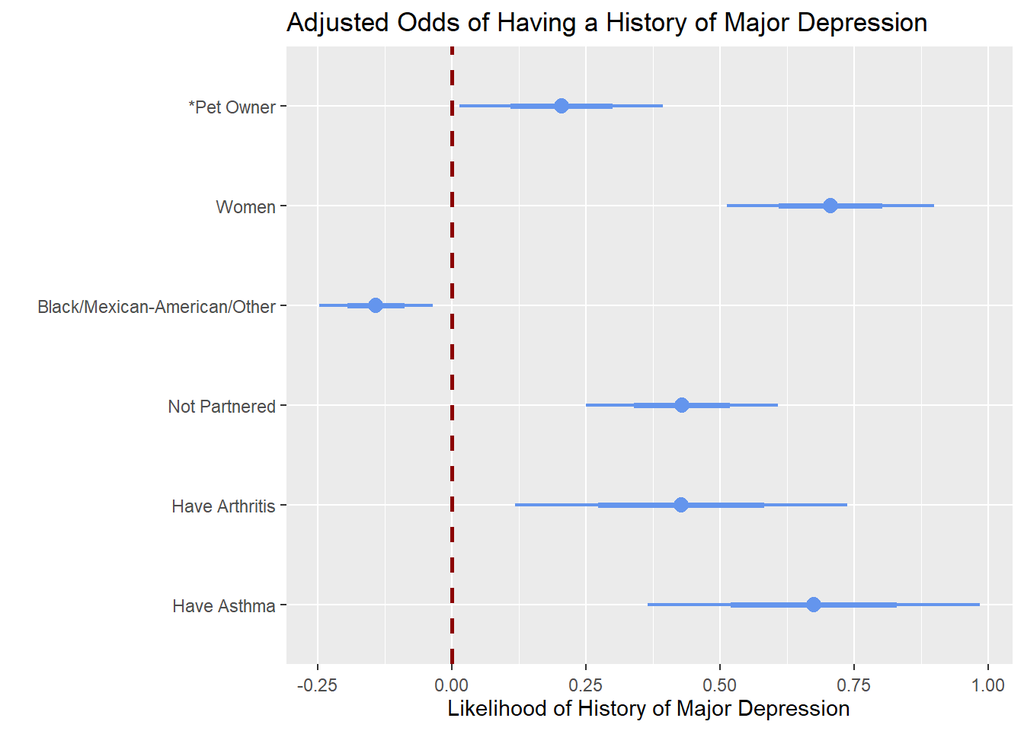

```r
coefplot(RedModel, decreasing = TRUE,
         #trans = invlogit,
         title = "Adjusted Odds of Having a History of Major Depression",
         xlab="Likelihood of History of Major Depression",
         ylim=-0.05:1,
         ylab = " ",
         cex = 1.5,
         color = "cornflowerblue", zeroColor="darkred",
         innerCI = 1, lwdInner = 1.4, outerCI = 2, lwdOuter = 0.8, pointSize = 3.1,
         intercept=FALSE,
         newNames=c(Asthma1="Have Asthma",Arthritis1="Have Arthritis",Marital1="Not Partnered",DMARETHN="Black/Mexican-American/Other",Men1="Women",Pet1="*Pet Owner"))
```

After adjusting for sex, race/ethnicity, marital status, arthritis status, asthma status, those who owned pets were roughly 23% more likely to report a history of major dpression than those without a pet. Women were more likely to report a history of major depression than men. Black/Mexican-American/Other were less likely to report a history of major depression than White. Those who are not partnered were more likely to report a history of major dpression than those partnered. Those who have arthritis were more likely to report a history of major depression than those who do not. And those with asthma were more likely to report a history of major depression than those who do not.

Although further data collection on variables like temporality would be needed for causality, I suspect that those with major depression may seek companionship in pets thus explaining the observation that pet owners are more likely to have a history of major depression. From prior knowledge, I suspected that women would have a higher odds of reporting a history of major depression even after adjustment. It appears like being Black/Mexican-American/Other makes you less likely to report a history of major depression. However, I think this may be due to mental health stigma and underreporting. In addition, from prior knowledge, I expected that those who are not partnered would be more likely to report a history of major depression. Lastly, I suspect that arthritis and/or asthma precede the incident of major depression.